# Download a species list and cross-reference with conservation status lists in Python

Knowing what species have been observed in a local area is a regular task for ecosystem management. Here we show how to make a species list with {galah-python} and how to cross-reference this list with threatened and sensitive species lists. We then show how to visualise this information as a waffle chart using {pywaffle} & {matplotlib}.

Eukaryota

Animalia

Plantae

Summaries

Python

Authors

Dax Kellie

Amanda Buyan

Published

February 12, 2024

Modified

March 5, 2026

#### Author

[Dax Kellie](https://labs.ala.org.au/about/Kellie_Dax/)  
[Amanda Buyan](https://labs.ala.org.au/about/Buyan_Amanda/)

#### Date

20 July 2025

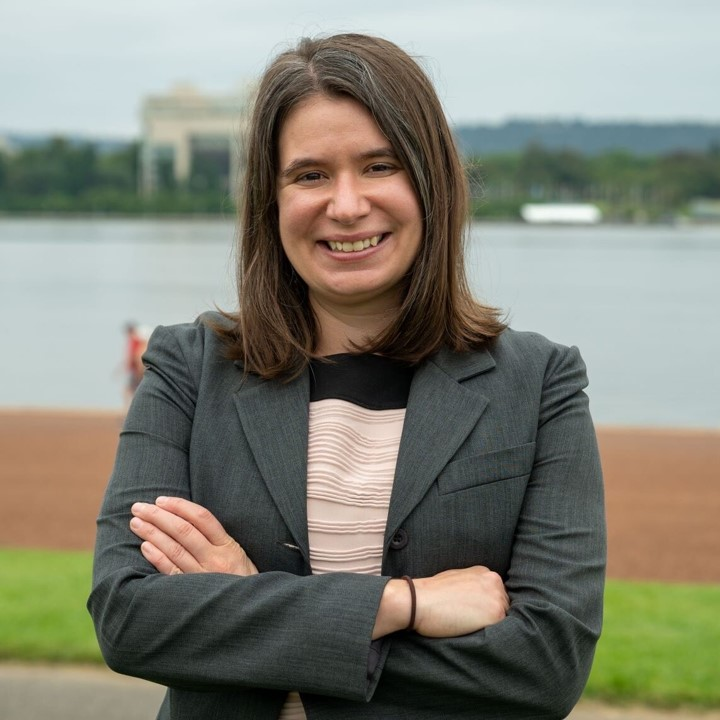

**Tip**

Updated 5 March, 2026

Knowing what species inhabit an area is important for conservation and ecosystem management. In particular, it can help us find how many known species are in a given area, and whether any species are vulnerable or endangered.

In this post, we will present two options, one using the [galah-python](https://galah.ala.org.au/Python/) package, the other using an external shapefile and list. Using either workflow, we will show you how to download a list of species within a Local Government Area (Shoalhaven, NSW), cross-reference this list with a state conservation status list, and visualise the number of threatened species in the region with [pywaffle](https://pywaffle.readthedocs.io/en/latest/) and [plotnine](https://plotnine.org/).

For those unfamiliar with Australian geography, Shoalhaven is located here:

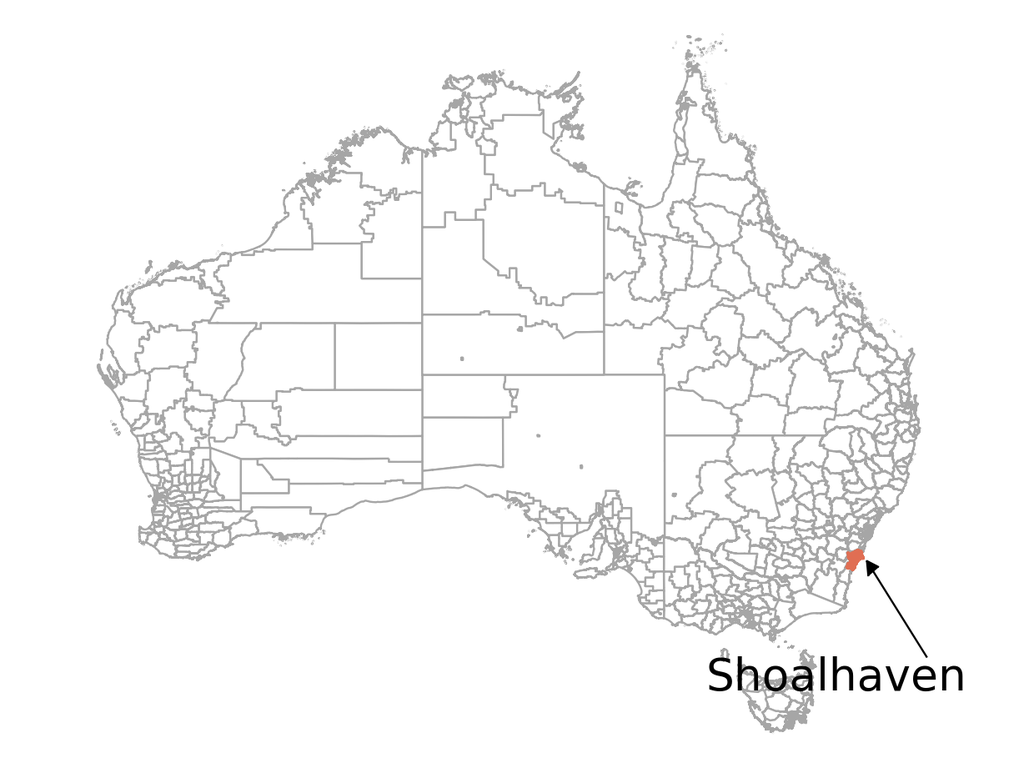

Let’s first load our packages. To download species lists, you will also need to enter a registered email with the ALA using `galah_config()`.

```python
import galah

galah.galah_config(email = "your-email-here") # ALA-registered email
```

# Download threatened species in an area

Choose which method you would like to view:

- `{galah-python}` (using `fields` downloaded from the Atlas of Living Australia)
- Downloaded shapefile + species list

The method you choose depends on whether the region or list you wish to return species for is already in `{galah-python}`, or whether you wish to filter for a more specific area defined by a separate shapefile or list. Keep in mind that using an external list may require additional work matching taxonomic names.

**galah-python**

### Search for fields

To find what exists in galah to help us narrow our query, we can use `search_all()` to search for available fields. A **field** in `{galah-python}` refers to a column or layer stored in a living atlas. Let’s do a text search to find what fields contain information on “Local Government Areas”.

```python
galah.search_all(fields = "Local Government Areas")
```

```
         id                                        description    type link
0     cl959  Local Government Areas 2011 Local Government A...  layers
1   cl11170  Local Government Areas 2023 Local Government A...  layers
2      cl23  Local Government Areas 2012 deprecated LGA Bou...  layers
3   cl10923  Local Government Areas PSMA 2018 PSMA Local Go...  layers
4  cl110923  Local Government Areas PSMA 2018 PSMA Local Go...  layers
```

The field `cl11170`[^1] contains the most recent available data (from 2023). We can preview what values are *within* field `cl11170` using `show_values()`.

```python
galah.show_values(field = 'cl11170')
```

```
       field            category
0    cl11170  Unincorporated ACT
1    cl11170            Brisbane
2    cl11170     Greater Geelong
3    cl11170         Moreton Bay
4    cl11170      East Gippsland
..       ...                 ...
542  cl11170    Peppermint Grove
543  cl11170          Woorabinda
544  cl11170         Wujal Wujal
545  cl11170           Cherbourg
546  cl11170             Belyuen

[547 rows x 2 columns]
```

There are lots of Local Government Areas! To check whether Shoalhaven is included, we can do a text search for values that match `'shoalhaven'`.

```python
galah.search_values(field = 'cl11170', value = 'shoalhaven')
```

```
     field    category
0  cl11170  Shoalhaven
```

### Download data

Using the `field` and `value` returned above, we can now build our query. We begin our query with `galah_call()` and filter to only Shoalhaven in the year 2024. Ending our query with `atlas_species()` will return a list of species.

```python
species_shoal = galah.atlas_species(filters = ['cl11170=Shoalhaven','year=2024'])

species_shoal
```

```
                                                Species                 Species Name    Scientific Name Authorship Taxon Rank   Kingdom      Phylum          Class           Order           Family          Genus              Vernacular Name
0     https://biodiversity.org.au/afd/taxa/e9d6fbbd-...       Phascolarctos cinereus              (Goldfuss, 1817)    species  Animalia    Chordata       Mammalia   Diprotodontia  Phascolarctidae  Phascolarctos                        Koala
1     https://biodiversity.org.au/afd/taxa/ae56080e-...    Malurus (Malurus) cyaneus                 (Ellis, 1782)    species  Animalia    Chordata           Aves   Passeriformes        Maluridae        Malurus            Superb Fairy-wren
2     https://biodiversity.org.au/afd/taxa/4dfe64e2-...     Trichoglossus moluccanus                (Gmelin, 1788)    species  Animalia    Chordata           Aves  Psittaciformes      Psittacidae  Trichoglossus             Rainbow Lorikeet
3     https://biodiversity.org.au/afd/taxa/5291343e-...           Gymnorhina tibicen                (Latham, 1801)    species  Animalia    Chordata           Aves   Passeriformes        Artamidae     Gymnorhina            Australian Magpie
4     https://biodiversity.org.au/afd/taxa/8117f68b-...            Corvus coronoides      Vigors & Horsfield, 1827    species  Animalia    Chordata           Aves   Passeriformes         Corvidae         Corvus             Australian Raven
...                                                 ...                          ...                           ...        ...       ...         ...            ...             ...              ...            ...                          ...
3078  https://id.biodiversity.org.au/taxon/apni/5178...            Eucalyptus rubida              H.Deane & Maiden    species   Plantae  Charophyta  Equisetopsida        Myrtales        Myrtaceae     Eucalyptus                   Candlebark
3079  https://id.biodiversity.org.au/taxon/apni/5178...        Tristaniopsis collina  Peter G.Wilson & J.T.Waterh.    species   Plantae  Charophyta  Equisetopsida        Myrtales        Myrtaceae  Tristaniopsis           Mountain Water Gum
3080  https://id.biodiversity.org.au/taxon/apni/5179...  Prasophyllum appendiculatum                      Nicholls    species   Plantae  Charophyta  Equisetopsida     Asparagales      Orchidaceae   Prasophyllum           Tailed Leek-orchid
3081  https://id.biodiversity.org.au/taxon/apni/5179...         Prasophyllum gracile                        Lindl.    species   Plantae  Charophyta  Equisetopsida     Asparagales      Orchidaceae   Prasophyllum  Little Laughing Leek Orchid
3082  https://id.biodiversity.org.au/taxon/apni/5179...       Prasophyllum sylvestre         R.J.Bates & D.L.Jones    species   Plantae  Charophyta  Equisetopsida     Asparagales      Orchidaceae   Prasophyllum           Forest Leek Orchid

[3083 rows x 11 columns]
```

`atlas_species()` returns taxonomic information at the species level (for more info, see the tab below). To make sure we return taxonomic information at the lowest level each occurrence was identified, we’ll `group_by(taxonConceptID)`, which is a unique ID attached to each occurrence record’s taxonomic identification (read the box below for more on what this means).

**Importantatlas_species() returns species-level information**

By default `atlas_species()` only returns taxonomic information at the species level. This means that if some species are identified to subspecies on a specific list like the NSW Conservation Status list, `atlas_species()` will return the species-level match, rather than the subspecies-level match. For example, the name `"Potorous tridactylus"` is returned instead of `"Potorous tridactylus tridactylus"`.

Grouping by `taxonConceptID` like we do below specifies that we wish to match to the identified taxon, rather than only to the species level.

```python
species_shoal = galah.atlas_species(filters = ['cl11170=Shoalhaven','year=2024'], group_by = 'taxonConceptID')

species_shoal
```

```
                                         taxonConceptID                 Species Name Scientific Name Authorship Taxon Rank   Kingdom      Phylum          Class           Order           Family          Genus              Vernacular Name
0     https://biodiversity.org.au/afd/taxa/e9d6fbbd-...       Phascolarctos cinereus           (Goldfuss, 1817)    species  Animalia    Chordata       Mammalia   Diprotodontia  Phascolarctidae  Phascolarctos                        Koala
1     https://biodiversity.org.au/afd/taxa/ae56080e-...    Malurus (Malurus) cyaneus              (Ellis, 1782)    species  Animalia    Chordata           Aves   Passeriformes        Maluridae        Malurus            Superb Fairy-wren
2     https://biodiversity.org.au/afd/taxa/4dfe64e2-...     Trichoglossus moluccanus             (Gmelin, 1788)    species  Animalia    Chordata           Aves  Psittaciformes      Psittacidae  Trichoglossus             Rainbow Lorikeet
3     https://biodiversity.org.au/afd/taxa/5291343e-...           Gymnorhina tibicen             (Latham, 1801)    species  Animalia    Chordata           Aves   Passeriformes        Artamidae     Gymnorhina            Australian Magpie
4     https://biodiversity.org.au/afd/taxa/8117f68b-...            Corvus coronoides   Vigors & Horsfield, 1827    species  Animalia    Chordata           Aves   Passeriformes         Corvidae         Corvus             Australian Raven
...                                                 ...                          ...                        ...        ...       ...         ...            ...             ...              ...            ...                          ...
4490  https://id.biodiversity.org.au/taxon/apni/5179...                  Asparagales                       Link      order   Plantae  Charophyta  Equisetopsida     Asparagales              NaN            NaN                          NaN
4491  https://id.biodiversity.org.au/taxon/apni/5179...  Prasophyllum appendiculatum                   Nicholls    species   Plantae  Charophyta  Equisetopsida     Asparagales      Orchidaceae   Prasophyllum           Tailed Leek-orchid
4492  https://id.biodiversity.org.au/taxon/apni/5179...         Prasophyllum gracile                     Lindl.    species   Plantae  Charophyta  Equisetopsida     Asparagales      Orchidaceae   Prasophyllum  Little Laughing Leek Orchid
4493  https://id.biodiversity.org.au/taxon/apni/5179...       Prasophyllum sylvestre      R.J.Bates & D.L.Jones    species   Plantae  Charophyta  Equisetopsida     Asparagales      Orchidaceae   Prasophyllum           Forest Leek Orchid
4494  https://id.biodiversity.org.au/taxon/apni/5179...                      Pinales                    Gorozh.      order   Plantae  Charophyta  Equisetopsida         Pinales              NaN            NaN                          NaN

[4495 rows x 11 columns]
```

**TipDownload record counts**

It’s also possible to return number of observations by ending our query with `atlas_counts()`. In this case, we can group by `scientificName` (the name of the lowest level the observation was identified).

```python
galah.atlas_counts(filters = ['cl11170=Shoalhaven','year=2024'],group_by = 'scientificName')
```

```
               scientificName  count
0                ACANTHIZIDAE      2
1                ACCIPITRIDAE      9
2             ACCIPITRIFORMES      4
3                   ACRIDIDAE      6
4              ACTINOPTERYGII      5
...                       ...    ...
4490  Zosteria fulvipubescens      1
4491   Zosteria rosevillensis      1
4492      Zosterops lateralis    810
4493                   Zoysia      1
4494         Zoysia macrantha      9

[4495 rows x 2 columns]
```

### Cross-reference with threatened species lists

Next we’ll compare our Shoalhaven species list `species_shoal` with a state-wide conservation status list. We can use `{galah-python}` to access lists that are available on the Atlas of Living Australia. Shoalhaven is within the state of New South Wales, so let’s search for “New South Wales” to see what state-specific lists are available.

```python
galah.search_all(lists = 'New South Wales')
```

```
  species_list_uid                                listName                                        description           listType           dateCreated           lastUpdated          lastUploaded           lastMatched               username fullName  itemCount           region category generalisation…
0            dr650   New South Wales : Conservation Status  Classification codes under the Threatened Spec...  CONSERVATION_LIST  2015-04-04T13:00:00Z  2026-02-27T00:39:46Z  2026-02-27T00:39:21Z  2026-02-27T00:39:21Z  amanda.buyan@csiro.au     None       1081  New South Wales      NaN            NaN…
1            dr487  New South Wales Sensitive Species List  The NSW Government [http://www.environment.nsw...     SENSITIVE_LIST  2013-06-20T14:00:00Z  2026-02-05T21:33:19Z  2026-02-05T21:33:12Z  2026-02-05T21:33:12Z  amanda.buyan@csiro.au     None        217  New South Wales                        …
```

Two lists are returned, and both appear relevant. With the help of some additional columns returned by `search_all()`—`listType`, `isAuthoritative` and `isThreatened`—we can learn more about which list suits our needs best. Although both lists are authoritative, only one list (`dr650`) contains threatened species whereas the other (`dr487`) contains sensitive species.

```python
galah.search_all(lists = 'New South Wales')[['species_list_uid', 'listType', 'isAuthoritative', 'isThreatened']]
```

```
  species_list_uid           listType  isAuthoritative  isThreatened
0            dr650  CONSERVATION_LIST             True          True
1            dr487     SENSITIVE_LIST             True         False
```

By specifying the ID `dr650` and using `show_values()`, we can view the complete New South Wales threatened species list.

```python
galah.show_values(field = 'dr650',lists = True)
```

```
           id                            name                commonName                                    scientificName                                               lsid dataResourceUid
0     7243482                     Delma impar    Striped Legless Lizard                                       Delma impar  https://biodiversity.org.au/afd/taxa/c7327642-...           dr650
1     7243887        Callocephalon fimbriatum        Gang-gang Cockatoo                          Callocephalon fimbriatum  https://biodiversity.org.au/afd/taxa/6c646af8-...           dr650
2     7243730             Cacophis harriettae       White-crowned Snake                               Cacophis harriettae  https://biodiversity.org.au/afd/taxa/20872a68-...           dr650
3     7243405         Litoria booroolongensis           Booroolong Frog                           Litoria booroolongensis  https://biodiversity.org.au/afd/taxa/9678cb19-...           dr650
4     7244319             Anthochaera phrygia         Regent Honeyeater                  Anthochaera (Xanthomyza) phrygia  https://biodiversity.org.au/afd/taxa/31869a0e-...           dr650
...       ...                             ...                       ...                                               ...                                                ...             ...
1076  7244009  Phyllodes imperialis smithersi       Pink Underwing Moth                    Phyllodes imperialis smithersi  https://biodiversity.org.au/afd/taxa/80cf15e7-...           dr650
1077  7243839              Lucasium microplax  Southern Sandplain Gecko                                Lucasium microplax  https://biodiversity.org.au/afd/taxa/8f94e876-...           dr650
1078  7243711           Aggreflorum benwellii                       NaN                            Leptospermum benwellii   https://id.biodiversity.org.au/node/apni/2899441           dr650
1079  7244329    Prasophyllum sp. Canobolense                       NaN  Prasophyllum sp. Canobolense (C. Bower ORG 7797)  https://id.biodiversity.org.au/taxon/apni/5179...           dr650
1080  7243942                Patersonia rosea                       NaN                                  Patersonia rosea  https://id.biodiversity.org.au/name/apni/51734419           dr650

[1081 rows x 6 columns]
```

```python
# get values
nsw_threatened = galah.show_values(field = 'dr650', lists = True, all_fields = True)

# rearrange columns so statuses are in front
nsw_threatened = nsw_threatened[['status','sourceStatus','IUCN_equivalent_status'] + [col for col in nsw_threatened.columns if col not in ['status','sourceStatus', 'IUCN_equivalent_status']]]
```

Adding status info can be handy if we want to join this with other information like record counts.

```python
# get record counts for each species on the NSW Conservation Status list
threatened_counts = galah.atlas_counts(
                      filters = ['species_list_uid=dr650','cl11170=Shoalhaven','year=2024'],
                      group_by = 'scientificName'
                    )

threatened_counts
```

```
                           scientificName  count
0          Angophora bakeri subsp. bakeri      1
1                     Antaresia childreni      1
2    Anthosachne kingiana subsp. kingiana      1
3                  Arctocephalus forsteri      2
4                      Arenaria interpres     92
..                                    ...    ...
104                        Xenus cinereus     36
105                    Zieria baeuerlenii      1
106                      Zieria granulata      1
107                    Zieria involucrata      1
108                        Zieria murphyi      2

[109 rows x 2 columns]
```

```python
# join counts to status information
threatened_counts_joined = pd.merge(threatened_counts,nsw_threatened,on='scientificName')
threatened_counts_joined = threatened_counts_joined[['scientificName', 'count', 'status', 'commonName'] + [col for col in threatened_counts_joined.columns if col not in ['scientificName', 'count', 'status', 'commonName']]]

threatened_counts_joined
```

```
                           scientificName  count                 status                  commonName           sourceStatus IUCN_equivalent_status       id                                  name                                               lsid dataResourceUid                verbatimScientificName   …
0          Angophora bakeri subsp. bakeri      1             Endangered                        None             Endangered             Endangered  7244230                        Angophora exul   https://id.biodiversity.org.au/node/apni/2913071           dr650                        Angophora exul   …
1                     Antaresia childreni      1             Vulnerable           Children's Python             Vulnerable             Vulnerable  7243944                   Antaresia childreni  https://biodiversity.org.au/afd/taxa/d1f64ac1-...           dr650                   Antaresia childreni   …
2    Anthosachne kingiana subsp. kingiana      1  Critically Endangered  Phillip Island Wheat Grass  Critically Endangered  Critically Endangered  7243811  Anthosachne kingiana subsp. kingiana  https://id.biodiversity.org.au/taxon/apni/5129...           dr650  Anthosachne kingiana subsp. kingiana  P…
3                  Arctocephalus forsteri      2             Vulnerable         Long-nosed Fur Seal             Vulnerable             Vulnerable  7244010                Arctocephalus forsteri  https://biodiversity.org.au/afd/taxa/598c4bf0-...           dr650                Arctocephalus forsteri   …
4                      Arenaria interpres     92             Vulnerable             Ruddy Turnstone             Vulnerable             Vulnerable  7243904                    Arenaria interpres  https://biodiversity.org.au/afd/taxa/2fa47871-...           dr650                    Arenaria interpres   …
..                                    ...    ...                    ...                         ...                    ...                    ...      ...                                   ...                                                ...             ...                                   ...   …
104                        Xenus cinereus     36             Vulnerable             Terek Sandpiper             Vulnerable             Vulnerable  7243480                        Xenus cinereus  https://biodiversity.org.au/afd/taxa/4090ad27-...           dr650                        Xenus cinereus   …
105                    Zieria baeuerlenii      1             Endangered            Bomaderry Zieria             Endangered             Endangered  7243361                    Zieria baeuerlenii   https://id.biodiversity.org.au/node/apni/2898536           dr650                    Zieria baeuerlenii   …
106                      Zieria granulata      1             Endangered            Illawarra Zieria             Endangered             Endangered  7243695                      Zieria granulata   https://id.biodiversity.org.au/node/apni/2916054           dr650                      Zieria granulata   …
107                    Zieria involucrata      1             Endangered                        None             Endangered             Endangered  7243559                    Zieria involucrata   https://id.biodiversity.org.au/node/apni/2888006           dr650                    Zieria involucrata   …
108                        Zieria murphyi      2             Vulnerable               Velvet Zieria             Vulnerable             Vulnerable  7243398                        Zieria murphyi   https://id.biodiversity.org.au/node/apni/2914587           dr650                        Zieria murphyi   …

[109 rows x 14 columns]
```

To return which species on the New South Wales Conservation Status List (`dr650`) were recorded in Shoalhaven in 2024, we can add `species_list_uid == dr650` as a filter to a query ending with `atlas_species()`. To make sure we return taxonomic information at the lowest level each occurrence was identified, we’ll `group_by(taxonConceptID)`.

```python
threatened = galah.atlas_species(
                filters = ['cl11170=Shoalhaven','year=2024','species_list_uid=dr650'],
                group_by = 'taxonConceptID'
              )

threatened
```

```
                                        taxonConceptID                          Species Name Scientific Name Authorship  Taxon Rank   Kingdom      Phylum          Class            Order           Family          Genus                Vernacular Name
0    https://biodiversity.org.au/afd/taxa/e9d6fbbd-...                Phascolarctos cinereus           (Goldfuss, 1817)     species  Animalia    Chordata       Mammalia    Diprotodontia  Phascolarctidae  Phascolarctos                          Koala
1    https://biodiversity.org.au/afd/taxa/ec2c76c7-...               Haematopus longirostris             Vieillot, 1817     species  Animalia    Chordata           Aves  Charadriiformes   Haematopodidae     Haematopus  Australian Pied Oystercatcher
2    https://biodiversity.org.au/afd/taxa/1f178bbc-...      Potorous tridactylus trisulcatus              (McCoy, 1865)  subspecies  Animalia    Chordata       Mammalia    Diprotodontia       Potoroidae       Potorous             Long-nosed Potoroo
3    https://biodiversity.org.au/afd/taxa/dc420306-...   Haliaeetus (Pontoaetus) leucogaster             (Gmelin, 1788)     species  Animalia    Chordata           Aves  Accipitriformes     Accipitridae     Haliaeetus        White-bellied Sea-eagle
4    https://biodiversity.org.au/afd/taxa/5ff29bca-...  Numenius (Numenius) madagascariensis           (Linnaeus, 1766)     species  Animalia    Chordata           Aves  Charadriiformes     Scolopacidae       Numenius                 Eastern Curlew
..                                                 ...                                   ...                        ...         ...       ...         ...            ...              ...              ...            ...                            ...
104   https://id.biodiversity.org.au/node/apni/2919589                   Grevillea rivularis    L.A.S.Johnson & McGill.     species   Plantae  Charophyta  Equisetopsida        Proteales       Proteaceae      Grevillea     Carrington Falls Grevillea
105  https://id.biodiversity.org.au/taxon/apni/5128...                    Epacris gnidioides         (Summerh.) E.A.Br.     species   Plantae  Charophyta  Equisetopsida         Ericales        Ericaceae        Epacris          Budawangs Cliff-heath
106  https://id.biodiversity.org.au/taxon/apni/5129...  Anthosachne kingiana subsp. kingiana                        NaN  subspecies   Plantae  Charophyta  Equisetopsida           Poales          Poaceae    Anthosachne     Phillip Island Wheat Grass
107  https://id.biodiversity.org.au/taxon/apni/5139...                  Caladenia tessellata                     Fitzg.     species   Plantae  Charophyta  Equisetopsida      Asparagales      Orchidaceae      Caladenia        Thick-lip Spider-orchid
108  https://id.biodiversity.org.au/taxon/apni/5141...                Pterostylis ventricosa     (D.L.Jones) G.N.Backh.     species   Plantae  Charophyta  Equisetopsida      Asparagales      Orchidaceae    Pterostylis                            NaN

[109 rows x 11 columns]
```

Note that status information is not included in the query above, but can be joined in the same way we added this status information to `threatened_counts`[^2].

```python
# select status columns, join status information
threatened = threatened.rename(columns={'Species Name': 'scientificName'})
threatened_status = pd.merge(nsw_threatened,threatened,on='scientificName')
threatened_status = threatened_status[['scientificName', 'status', 'sourceStatus'] + [col for col in threatened_status.columns if col not in ['scientificName', 'status', 'sourceStatus']]]

threatened_status
```

```
                           scientificName                 status           sourceStatus IUCN_equivalent_status       id                                  name                  commonName                                               lsid dataResourceUid                verbatimScientificName          …
0                Callocephalon fimbriatum             Endangered             Endangered             Endangered  7243887              Callocephalon fimbriatum          Gang-gang Cockatoo  https://biodiversity.org.au/afd/taxa/6c646af8-...           dr650              Callocephalon fimbriatum          …
1        Calidris (Calidris) tenuirostris             Vulnerable             Vulnerable             Vulnerable  7243934                 Calidris tenuirostris                  Great Knot  https://biodiversity.org.au/afd/taxa/3e9c17c9-...           dr650                 Calidris tenuirostris          …
2             Ninox (Rhabdoglaux) strenua             Vulnerable             Vulnerable             Vulnerable  7244303                         Ninox strenua                Powerful Owl  https://biodiversity.org.au/afd/taxa/d1c5dee0-...           dr650                         Ninox strenua          …
3                           Limosa limosa             Endangered             Endangered             Endangered  7243263                         Limosa limosa         Black-tailed Godwit  https://biodiversity.org.au/afd/taxa/70b173fb-...           dr650                         Limosa limosa          …
4    Numenius (Numenius) madagascariensis  Critically Endangered  Critically Endangered  Critically Endangered  7244110             Numenius madagascariensis              Eastern Curlew  https://biodiversity.org.au/afd/taxa/5ff29bca-...           dr650             Numenius madagascariensis          …
..                                    ...                    ...                    ...                    ...      ...                                   ...                         ...                                                ...             ...                                   ...          …
104  Anthosachne kingiana subsp. kingiana  Critically Endangered  Critically Endangered  Critically Endangered  7243811  Anthosachne kingiana subsp. kingiana  Phillip Island Wheat Grass  https://id.biodiversity.org.au/taxon/apni/5129...           dr650  Anthosachne kingiana subsp. kingiana   Phillip…
105        Miniopterus orianae oceanensis             Vulnerable             Vulnerable             Vulnerable  7243507        Miniopterus orianae oceanensis     Eastern Bent-winged Bat  https://biodiversity.org.au/afd/taxa/57842363-...           dr650        Miniopterus orianae oceanensis        La…
106      Potorous tridactylus trisulcatus             Vulnerable             Vulnerable             Vulnerable  7243357      Potorous tridactylus trisulcatus          Long-nosed Potoroo  https://biodiversity.org.au/afd/taxa/1f178bbc-...           dr650      Potorous tridactylus trisulcatus  Southern…
107                    Epacris gnidioides             Vulnerable             Vulnerable             Vulnerable  7243424                    Epacris gnidioides       Budawangs Cliff-heath  https://id.biodiversity.org.au/taxon/apni/5128...           dr650                    Epacris gnidioides        Bu…
108                       Litoria watsoni             Endangered             Endangered             Endangered  7244177                       Litoria watsoni          Watson's Tree Frog  https://biodiversity.org.au/afd/taxa/95cf54aa-...           dr650                       Litoria watsoni          …

[109 rows x 23 columns]
```

**Shapefile + list**

### Download shapefile

To retrieve the spatial outline of Shoalhaven, let’s download the latest Local Government Areas data from the [Australian Bureau of Statistics Digital Boundary files page](https://www.abs.gov.au/statistics/standards/australian-statistical-geography-standard-asgs-edition-3/jul2021-jun2026/access-and-downloads/digital-boundary-files). Find “Local Government Areas - 2025 - Shapefile” and click “Download ZIP”. Save the zip folder in your current directory and unzip it.

Let’s read the file into Python.

```python
lgas = gpd.read_file('LGA_2025_AUST_GDA2020.zip')
lgas
```

```
    LGA_CODE23                             LGA_NAME23 STE_CODE21                    STE_NAME21 AUS_CODE21         AUS_NAME21    AREASQKM                                         LOCI_URI21                                           geometry
0        10050                                 Albury          1               New South Wales        AUS          Australia    305.6386  https://linked.data.gov.au/dataset/asgsed3/LGA...  POLYGON ((146.86566 -36.07292, 146.86512 -36.0...
1        10180                               Armidale          1               New South Wales        AUS          Australia   7809.4406  https://linked.data.gov.au/dataset/asgsed3/LGA...  POLYGON ((152.38816 -30.52639, 152.38812 -30.5...
2        10250                                Ballina          1               New South Wales        AUS          Australia    484.9692  https://linked.data.gov.au/dataset/asgsed3/LGA...  MULTIPOLYGON (((153.57106 -28.87381, 153.57106...
3        10300                              Balranald          1               New South Wales        AUS          Australia  21690.7493  https://linked.data.gov.au/dataset/asgsed3/LGA...  POLYGON ((143.00433 -33.78164, 143.01538 -33.7...
4        10470                               Bathurst          1               New South Wales        AUS          Australia   3817.8645  https://linked.data.gov.au/dataset/asgsed3/LGA...  POLYGON ((149.84877 -33.52784, 149.84864 -33.5...
..         ...                                    ...        ...                           ...        ...                ...         ...                                                ...                                                ...
561      89799  Migratory - Offshore - Shipping (ACT)          8  Australian Capital Territory        AUS          Australia         NaN  https://linked.data.gov.au/dataset/asgsed3/LGA...                                               None
562      99399            Unincorp. Other Territories          9             Other Territories        AUS          Australia    105.8806  https://linked.data.gov.au/dataset/asgsed3/LGA...  MULTIPOLYGON (((167.94747 -29.12757, 167.94748...
563      99499                  No usual address (OT)          9             Other Territories        AUS          Australia         NaN  https://linked.data.gov.au/dataset/asgsed3/LGA...                                               None
564      99799   Migratory - Offshore - Shipping (OT)          9             Other Territories        AUS          Australia         NaN  https://linked.data.gov.au/dataset/asgsed3/LGA...                                               None
565      ZZZZZ                      Outside Australia          Z             Outside Australia        ZZZ  Outside Australia         NaN  https://linked.data.gov.au/dataset/asgsed3/LGA...                                               None

[566 rows x 9 columns]
```

Now let’s transform our shapefile to use the Coordinate Reference System (CRS) [EPSG](https://en.wikipedia.org/wiki/EPSG_Geodetic_Parameter_Dataset):4326 (the standard used in cartography and GPS, also known as [WGS84](https://en.wikipedia.org/wiki/World_Geodetic_System)) so that it matches the projection of our data from the ALA [^3].

```python
lgas_wgs84 = lgas.to_crs(4326)
```

We will also simplify the shapefile[^4] using `shapely.simplify()` from the [shapely package](https://shapely.readthedocs.io/en/2.0.6/index.html) because complex shapefiles can sometimes cause problems with sending queries to the ALA.

```python
shoalhaven = lgas_wgs84[lgas_wgs84['LGA_NAME23'] == 'Shoalhaven']
shoalhaven_simplify = shapely.simplify(shoalhaven['geometry'][shoalhaven.index[0]],tolerance=4)
```

### Download data

Now that `shoalhaven` contains our LGA shape, we can build our query. Once again, we’ll begin with `galah_call()` and filter to only records from 2024. We can specify that we want records within `shoalhaven` using `geolocate()`. To make sure we return taxonomic information at the level occurrences were identified to, we’ll `group_by(taxonConceptID)`, which is a unique ID attached to each occurrence record’s taxonomic identification (read the box below for more on what this means). Finally, we can return a species list by ending our query with `atlas_species()`.

**Importantatlas_species() returns species-level information**

By default `atlas_species()` only returns taxonomic information at the species level. This means that if some species are identified to subspecies on a specific list like the NSW Conservation Status list, `atlas_species()` will return the species-level match, rather than the subspecies-level match. For example, the name `"Potorous tridactylus"` is returned instead of `"Potorous tridactylus tridactylus"`.

Grouping by `taxonConceptID` like we do below specifies that we wish to match to the identified taxon, rather than only to the species level.

```python
# shoalhaven index
species_shoal = galah.atlas_species(
                  filters = ['year=2024'],
                  polygon = shoalhaven_simplify,
                  group_by = 'taxonConceptID'
                )

species_shoal
```

```
                                         taxonConceptID                       Species Name Scientific Name Authorship Taxon Rank   Kingdom      Phylum          Class           Order           Family          Genus              Vernacular Name
0     https://biodiversity.org.au/afd/taxa/e9d6fbbd-...             Phascolarctos cinereus           (Goldfuss, 1817)    species  Animalia    Chordata       Mammalia   Diprotodontia  Phascolarctidae  Phascolarctos                        Koala
1     https://biodiversity.org.au/afd/taxa/f2f43ef9-...                 Macropus giganteus                 Shaw, 1790    species  Animalia    Chordata       Mammalia   Diprotodontia     Macropodidae       Macropus        Eastern Grey Kangaroo
2     https://biodiversity.org.au/afd/taxa/4dfe64e2-...           Trichoglossus moluccanus             (Gmelin, 1788)    species  Animalia    Chordata           Aves  Psittaciformes      Psittacidae  Trichoglossus             Rainbow Lorikeet
3     https://biodiversity.org.au/afd/taxa/1fc76c4d-...       Dacelo (Dacelo) novaeguineae            (Hermann, 1783)    species  Animalia    Chordata           Aves   Coraciiformes      Alcedinidae         Dacelo          Laughing Kookaburra
4     https://biodiversity.org.au/afd/taxa/5e0f496f-...  Platycercus (Platycercus) elegans             (Gmelin, 1788)    species  Animalia    Chordata           Aves  Psittaciformes      Psittacidae    Platycercus              Crimson Rosella
...                                                 ...                                ...                        ...        ...       ...         ...            ...             ...              ...            ...                          ...
3235  https://id.biodiversity.org.au/taxon/apni/5179...        Prasophyllum appendiculatum                   Nicholls    species   Plantae  Charophyta  Equisetopsida     Asparagales      Orchidaceae   Prasophyllum           Tailed Leek-orchid
3236  https://id.biodiversity.org.au/taxon/apni/5179...            Prasophyllum brevilabre           (Lindl.) Hook.f.    species   Plantae  Charophyta  Equisetopsida     Asparagales      Orchidaceae   Prasophyllum     Short-lipped Leek Orchid
3237  https://id.biodiversity.org.au/taxon/apni/5179...               Prasophyllum gracile                     Lindl.    species   Plantae  Charophyta  Equisetopsida     Asparagales      Orchidaceae   Prasophyllum  Little Laughing Leek Orchid
3238  https://id.biodiversity.org.au/taxon/apni/5179...             Prasophyllum sylvestre      R.J.Bates & D.L.Jones    species   Plantae  Charophyta  Equisetopsida     Asparagales      Orchidaceae   Prasophyllum           Forest Leek Orchid
3239  https://id.biodiversity.org.au/taxon/apni/5179...                            Plantae                    Haeckel    kingdom   Plantae         NaN            NaN             NaN              NaN            NaN                          NaN

[3240 rows x 11 columns]
```

**TipDownload record counts**

It’s also possible to return the observations counts by ending our query with `atlas_counts()`. In this case, we can group by `scientificName` (the name of the lowest level the observation was identified).

```python
galah.atlas_counts(
  filters = ['year=2024'],
  polygon = shoalhaven_simplify,
  group_by = 'scientificName'
)
```

```
                            scientificName  count
0      'Ochlerotatus' ('Finlaya') britteni      1
1      'Ochlerotatus' ('Finlaya') mallochi      1
2      'Ochlerotatus' ('Finlaya') wasselli      1
3                             ACALYPTRATAE    469
4                          ACANTHASTERIDAE      1
...                                    ...    ...
58189                      Zyzomys argurus      7
58190                        Zyzomys maini      1
58191                             Zyzzyzus      1
58192           [Pytinaea group] schistopa     42
58193                         ×Graptosedum      1

[58194 rows x 2 columns]
```

### Use external list

We can use our own conservation status lists from an external source to compare to our Shoalhaven species list. As an example, we are using the the New South Wales Conservation Status List downloaded from the [NSW Bionet Atlas website](https://atlas.bionet.nsw.gov.au/UI_Modules/ATLAS_/AtlasSearch.aspx)[^5].

**NoteWhat options did we choose to download our list?**

We downloaded this list on 2025/07/08. To download a complete NSW threatened species list, we selected the following options:

- Which species or group? *All entities*
- Legal status? *Select records that fall under one or more categories* ➝ *Threatened NSW*
- What area? *Entire area*
- Period of records? *All records*
- Status? *Valid records only*

Save the downloaded `.xls` file in your working directory. We’ll read in our `.xls` file, which we have renamed to `nsw_threatened.xls`.

```python
nsw_threatened_list = pd.read_excel('path/to/nsw_threatened.xlsx', skiprows = 3) # skip first 3 rows
```

**Warninglibxls error**

It’s possible you might receive the following error.

```
Error:
  filepath: [path-to-file]
  libxls error: Unable to open file
```

This relates to a formatting issue preventing `read_excel()` from reading the file correctly, which seems related to the way BioNet saves its files. To fix this issue, open the list file on your computer, then re-save the file as a `.xlsx` document (File ➝ Save As ➝ select file format`.xlsx` ➝ Save). Then you can use `read_excel()` to read the new file in.

```python
nsw_threatened_list = pd.read_excel('path/to/nsw_threatened.xlsx', skiprows = 3) # skip first three rows
```

### Cross-reference with threatened species lists

```python
from janitor import clean_names

nsw_threatened_list = clean_names(nsw_threatened_list)

nsw_threatened_list
```

```
       kingdom     class          family species_code                                    scientific_name  exotic                                        common_name nsw_status comm_status records  info
0     Animalia  Amphibia  Myobatrachidae         3007                                   Assa darlingtoni     NaN                                       Pouched Frog        V,P           V     656   NaN
1     Animalia  Amphibia  Myobatrachidae         3135                                     Crinia sloanei     NaN                                   Sloane's Froglet       E1,P           E     849   NaN
2     Animalia  Amphibia  Myobatrachidae         3137                                     Crinia tinnula     NaN                                     Wallum Froglet        V,P         NaN    2653   NaN
3     Animalia  Amphibia  Myobatrachidae         3073                                  ^Mixophyes balbus     NaN                                    Stuttering Frog     E1,P,2           V    2013   NaN
4     Animalia  Amphibia  Myobatrachidae         3008                                  ^Mixophyes fleayi     NaN                                Fleay's Barred Frog     E1,P,2           E    1539   NaN
...        ...       ...             ...          ...                                                ...     ...                                                ...        ...         ...     ...   ...
1213    Threat       NaN             NaN          NaN  Predation by the European Red Fox Vulpes Vulpe...     NaN  Predation by the European Red Fox Vulpes Vulpe...        KTP         KTP       P   NaN
1214    Threat       NaN             NaN          NaN  Predation by the Feral Cat Felis catus (Linnae...     NaN  Predation by the Feral Cat Felis catus (Linnae...        KTP         KTP       P   NaN
1215    Threat       NaN             NaN          NaN  Predation by the Ship Rat Rattus rattus on Lor...     NaN  Predation by the Ship Rat Rattus rattus on Lor...        KTP         KTP       P   NaN
1216    Threat       NaN             NaN          NaN  Predation, habitat degradation, competition an...     NaN  Predation, habitat degradation, competition an...        KTP         KTP       P   NaN
1217    Threat       NaN             NaN          NaN                Removal of dead wood and dead trees     NaN                Removal of dead wood and dead trees        KTP         NaN       P   NaN

[1218 rows x 11 columns]
```

Now we can filter our Shoalhaven list to only those that match names in `nsw_threatened_list`.

```python
species_shoal = clean_names(species_shoal)
threatened_filter = species_shoal[species_shoal['species_name'].isin(nsw_threatened_list['scientific_name'].unique())].reset_index(drop=True)

threatened_filter
```

```
                                       taxonconceptid                          species_name                         scientific_name_authorship  taxon_rank   kingdom      phylum          class              order            family           genus                vernacular_name
0   https://biodiversity.org.au/afd/taxa/e9d6fbbd-...                Phascolarctos cinereus                                   (Goldfuss, 1817)     species  Animalia    Chordata       Mammalia      Diprotodontia   Phascolarctidae   Phascolarctos                          Koala
1   https://biodiversity.org.au/afd/taxa/ec2c76c7-...               Haematopus longirostris                                     Vieillot, 1817     species  Animalia    Chordata           Aves    Charadriiformes    Haematopodidae      Haematopus  Australian Pied Oystercatcher
2   https://biodiversity.org.au/afd/taxa/73c23669-...                    Dasyurus maculatus                                       (Kerr, 1792)     species  Animalia    Chordata       Mammalia     Dasyuromorphia        Dasyuridae        Dasyurus                     Bindjulang
3   https://biodiversity.org.au/afd/taxa/ff90b63a-...                      Perameles nasuta                                     Geoffroy, 1804     species  Animalia    Chordata       Mammalia    Peramelemorphia       Peramelidae       Perameles           Long-nosed Bandicoot
4   https://biodiversity.org.au/afd/taxa/05b0f88f-...                Haematopus fuliginosus                                        Gould, 1845     species  Animalia    Chordata           Aves    Charadriiformes    Haematopodidae      Haematopus            Sooty Oystercatcher
5   https://biodiversity.org.au/afd/taxa/2e27790b-...                 Pycnoptilus floccosus                                        Gould, 1851     species  Animalia    Chordata           Aves      Passeriformes      Acanthizidae     Pycnoptilus                      Pilotbird
6   https://biodiversity.org.au/afd/taxa/f9a68186-...                   Esacus magnirostris                                     Vieillot, 1818     species  Animalia    Chordata           Aves    Charadriiformes        Burhinidae          Esacus             Beach Stone-curlew
7   https://biodiversity.org.au/afd/taxa/6485cd0c-...                 Hirundapus caudacutus                                     (Latham, 1801)     species  Animalia    Chordata           Aves        Apodiformes          Apodidae      Hirundapus      White-throated Needletail
8   https://biodiversity.org.au/afd/taxa/77bcae99-...                Pteropus poliocephalus                                     Temminck, 1825     species  Animalia    Chordata       Mammalia         Chiroptera      Pteropodidae        Pteropus         Grey-headed Flying-fox
9   https://biodiversity.org.au/afd/taxa/2a4e373b-...              Dromaius novaehollandiae                                     (Latham, 1790)     species  Animalia    Chordata           Aves   Struthioniformes       Casuariidae        Dromaius                            Emu
10  https://biodiversity.org.au/afd/taxa/5e2dc7c9-...                    Petauroides volans                                       (Kerr, 1792)     species  Animalia    Chordata       Mammalia      Diprotodontia   Pseudocheiridae     Petauroides        Southern Greater Glider
11   https://id.biodiversity.org.au/node/apni/2889553                Plinthanthesis rodwayi                              (C.E.Hubb.) S.T.Blake     species   Plantae  Charophyta  Equisetopsida             Poales           Poaceae  Plinthanthesis        Budawangs Wallaby Grass
12  https://biodiversity.org.au/afd/taxa/35359d1d-...                    Sternula albifrons                                     (Pallas, 1764)     species  Animalia    Chordata           Aves    Charadriiformes           Laridae        Sternula                    Little Tern
13  https://biodiversity.org.au/afd/taxa/61e18b9c-...                    Petaurus australis                                         Shaw, 1791     species  Animalia    Chordata       Mammalia      Diprotodontia        Petauridae        Petaurus          Yellow-bellied Glider
```

[output cut: 35 more lines]

To preserve status information, instead we can join `species_shoal` and `nsw_threatened_list` dataframes, which will retain columns while still filtering results.

```python
threatened_joined = pd.merge(species_shoal, nsw_threatened_list,
                             left_on = 'species_name', right_on = 'scientific_name'
                             ).dropna(subset = ['nsw_status'])

threatened_joined
```

```
                                       taxonconceptid                          species_name                         scientific_name_authorship  taxon_rank kingdom_x      phylum        class_x              order          family_x           genus                vernacular_name kingdom_y   class_y     …
0   https://biodiversity.org.au/afd/taxa/e9d6fbbd-...                Phascolarctos cinereus                                   (Goldfuss, 1817)     species  Animalia    Chordata       Mammalia      Diprotodontia   Phascolarctidae   Phascolarctos                          Koala  Animalia  Mammalia     …
1   https://biodiversity.org.au/afd/taxa/ec2c76c7-...               Haematopus longirostris                                     Vieillot, 1817     species  Animalia    Chordata           Aves    Charadriiformes    Haematopodidae      Haematopus  Australian Pied Oystercatcher  Animalia      Aves     …
2   https://biodiversity.org.au/afd/taxa/73c23669-...                    Dasyurus maculatus                                       (Kerr, 1792)     species  Animalia    Chordata       Mammalia     Dasyuromorphia        Dasyuridae        Dasyurus                     Bindjulang  Animalia  Mammalia     …
3   https://biodiversity.org.au/afd/taxa/ff90b63a-...                      Perameles nasuta                                     Geoffroy, 1804     species  Animalia    Chordata       Mammalia    Peramelemorphia       Peramelidae       Perameles           Long-nosed Bandicoot  Animalia  Mammalia     …
4   https://biodiversity.org.au/afd/taxa/ff90b63a-...                      Perameles nasuta                                     Geoffroy, 1804     species  Animalia    Chordata       Mammalia    Peramelemorphia       Peramelidae       Perameles           Long-nosed Bandicoot  Animalia  Mammalia     …
5   https://biodiversity.org.au/afd/taxa/05b0f88f-...                Haematopus fuliginosus                                        Gould, 1845     species  Animalia    Chordata           Aves    Charadriiformes    Haematopodidae      Haematopus            Sooty Oystercatcher  Animalia      Aves     …
6   https://biodiversity.org.au/afd/taxa/2e27790b-...                 Pycnoptilus floccosus                                        Gould, 1851     species  Animalia    Chordata           Aves      Passeriformes      Acanthizidae     Pycnoptilus                      Pilotbird  Animalia      Aves     …
7   https://biodiversity.org.au/afd/taxa/f9a68186-...                   Esacus magnirostris                                     Vieillot, 1818     species  Animalia    Chordata           Aves    Charadriiformes        Burhinidae          Esacus             Beach Stone-curlew  Animalia      Aves     …
8   https://biodiversity.org.au/afd/taxa/6485cd0c-...                 Hirundapus caudacutus                                     (Latham, 1801)     species  Animalia    Chordata           Aves        Apodiformes          Apodidae      Hirundapus      White-throated Needletail  Animalia      Aves     …
9   https://biodiversity.org.au/afd/taxa/77bcae99-...                Pteropus poliocephalus                                     Temminck, 1825     species  Animalia    Chordata       Mammalia         Chiroptera      Pteropodidae        Pteropus         Grey-headed Flying-fox  Animalia  Mammalia     …
10  https://biodiversity.org.au/afd/taxa/2a4e373b-...              Dromaius novaehollandiae                                     (Latham, 1790)     species  Animalia    Chordata           Aves   Struthioniformes       Casuariidae        Dromaius                            Emu  Animalia      Aves     …
11  https://biodiversity.org.au/afd/taxa/5e2dc7c9-...                    Petauroides volans                                       (Kerr, 1792)     species  Animalia    Chordata       Mammalia      Diprotodontia   Pseudocheiridae     Petauroides        Southern Greater Glider  Animalia  Mammalia     …
12   https://id.biodiversity.org.au/node/apni/2889553                Plinthanthesis rodwayi                              (C.E.Hubb.) S.T.Blake     species   Plantae  Charophyta  Equisetopsida             Poales           Poaceae  Plinthanthesis        Budawangs Wallaby Grass   Plantae     Flora     …
13  https://biodiversity.org.au/afd/taxa/35359d1d-...                    Sternula albifrons                                     (Pallas, 1764)     species  Animalia    Chordata           Aves    Charadriiformes           Laridae        Sternula                    Little Tern  Animalia      Aves     …
```

[output cut: 39 more lines]

**TipSpecies with more than one status**

Species lists from BioNet Atlas can sometimes return both species and specific populations of the same species with their own conservation status, respectively. When matching species names, this means there can be multiple matches for the same species. For example, there are seperate conservation statuses assigned to the Yellow bellied glider and a Yellow bellied glider population in the Bago Plateau.

```python
threatened_joined[
  threatened_joined['species_name'] == 'Petaurus australis'
][['species_name', 'common_name', 'nsw_status']]
```

```
          species_name                                        common_name nsw_status
14  Petaurus australis                              Yellow-bellied Glider        V,P
15  Petaurus australis  Yellow-bellied Glider population on the Bago P...     E2,V,P
```

These multiple statuses explain why there are several more rows when we join dataframes (`threatened_joined`) compared to when we filter by species names (`threatened_filter`).

**WarningNames matching**

You might notice that fewer species are returned when using an externally downloaded list than using galah. This discrepancy is due to differences in scientific names between those on the BioNet Atlas and those on the ALA. Names mismatches are a risk when using external species lists. Additional work is usually needed to avoid unexpected mismatches. The *Cleaning Biodiversity Data in R* book details [some methods for finding name synonyms](https://cleaning-data-r.ala.org.au/3_ecological-cleaning/taxonomic-validation.html#checking-for-synonyms), but amending taxonomic names can be difficult.

When ALA ingests data, it matches those data to the ALA’s taxonomic backbone, with the goal of minimising name mismatches. We recommend using galah because it makes names matching easier. However, not all lists exist on the ALA, so some tasks inevitably require matching to externally downloaded lists.

To use this list for summarising or plotting, it might be useful to add to `threatened_joined` status information for each species as vulnerable, endangered, critically endangered or extinct. To add this info, we’ll extract the first value of `nsw_status` by removing everything after the first comma and save that value in `nsw_status_extracted`. Then we’ll recode these values[^6] and save them in `nsw_status_simple`.

```python
# clean statuses
statuses = {'V': 'Vulnerable', 'E1': 'Endangered','E2': 'Endangered',
            'E3': 'Endangered','E4A': 'Critically Endangered',
            'E4': 'Extinct'}
threatened_clean = threatened_joined.copy()
threatened_clean['nsw_status_extracted'] = threatened_clean['nsw_status'].copy().replace({',P': ''},regex=True)
threatened_clean['nsw_status_simple'] = threatened_clean['nsw_status_extracted'].copy().replace(statuses)

# reposition columns
threatened_clean = threatened_clean[['nsw_status', 'nsw_status_extracted', 'nsw_status_simple', 'species_name'] + [col for col in threatened_clean.columns if col not in ['nsw_status', 'nsw_status_extracted', 'nsw_status_simple', 'species_name']]]

threatened_clean
```

```
   nsw_status nsw_status_extracted      nsw_status_simple                          species_name                                     taxonconceptid                         scientific_name_authorship  taxon_rank kingdom_x      phylum        class_x              order          family_x           genus …
0        E1,P                   E1             Endangered                Phascolarctos cinereus  https://biodiversity.org.au/afd/taxa/e9d6fbbd-...                                   (Goldfuss, 1817)     species  Animalia    Chordata       Mammalia      Diprotodontia   Phascolarctidae   Phascolarctos …
1        E1,P                   E1             Endangered               Haematopus longirostris  https://biodiversity.org.au/afd/taxa/ec2c76c7-...                                     Vieillot, 1817     species  Animalia    Chordata           Aves    Charadriiformes    Haematopodidae      Haematopus …
2         V,P                    V             Vulnerable                    Dasyurus maculatus  https://biodiversity.org.au/afd/taxa/73c23669-...                                       (Kerr, 1792)     species  Animalia    Chordata       Mammalia     Dasyuromorphia        Dasyuridae        Dasyurus …
3        E2,P                   E2             Endangered                      Perameles nasuta  https://biodiversity.org.au/afd/taxa/ff90b63a-...                                     Geoffroy, 1804     species  Animalia    Chordata       Mammalia    Peramelemorphia       Peramelidae       Perameles …
4        E2,P                   E2             Endangered                      Perameles nasuta  https://biodiversity.org.au/afd/taxa/ff90b63a-...                                     Geoffroy, 1804     species  Animalia    Chordata       Mammalia    Peramelemorphia       Peramelidae       Perameles …
5         V,P                    V             Vulnerable                Haematopus fuliginosus  https://biodiversity.org.au/afd/taxa/05b0f88f-...                                        Gould, 1845     species  Animalia    Chordata           Aves    Charadriiformes    Haematopodidae      Haematopus …
6         V,P                    V             Vulnerable                 Pycnoptilus floccosus  https://biodiversity.org.au/afd/taxa/2e27790b-...                                        Gould, 1851     species  Animalia    Chordata           Aves      Passeriformes      Acanthizidae     Pycnoptilus …
7       E4A,P                  E4A  Critically Endangered                   Esacus magnirostris  https://biodiversity.org.au/afd/taxa/f9a68186-...                                     Vieillot, 1818     species  Animalia    Chordata           Aves    Charadriiformes        Burhinidae          Esacus …
8         V,P                    V             Vulnerable                 Hirundapus caudacutus  https://biodiversity.org.au/afd/taxa/6485cd0c-...                                     (Latham, 1801)     species  Animalia    Chordata           Aves        Apodiformes          Apodidae      Hirundapus …
9         V,P                    V             Vulnerable                Pteropus poliocephalus  https://biodiversity.org.au/afd/taxa/77bcae99-...                                     Temminck, 1825     species  Animalia    Chordata       Mammalia         Chiroptera      Pteropodidae        Pteropus …
10       E2,P                   E2             Endangered              Dromaius novaehollandiae  https://biodiversity.org.au/afd/taxa/2a4e373b-...                                     (Latham, 1790)     species  Animalia    Chordata           Aves   Struthioniformes       Casuariidae        Dromaius …
11       E1,P                   E1             Endangered                    Petauroides volans  https://biodiversity.org.au/afd/taxa/5e2dc7c9-...                                       (Kerr, 1792)     species  Animalia    Chordata       Mammalia      Diprotodontia   Pseudocheiridae     Petauroides …
12        E4A                  E4A  Critically Endangered                Plinthanthesis rodwayi   https://id.biodiversity.org.au/node/apni/2889553                              (C.E.Hubb.) S.T.Blake     species   Plantae  Charophyta  Equisetopsida             Poales           Poaceae  Plinthanthesis …
13       E1,P                   E1             Endangered                    Sternula albifrons  https://biodiversity.org.au/afd/taxa/35359d1d-...                                     (Pallas, 1764)     species  Animalia    Chordata           Aves    Charadriiformes           Laridae        Sternula …
```

[output cut: 39 more lines]

Whichever method you’ve followed, you will end up with very similar datasets containing threatened species and their statuses, though the number of matched species might differ[^7].

**galah**

```python
import itables
from IPython.display import HTML, display
html = itables.to_html_datatable(threatened_status)
HTML(html)
```

[figure not shown]

Loading ITables v2.7.0 from the internet... (need [help](https://mwouts.github.io/itables/troubleshooting.html)?)

**Shapefile + list**

```python
import itables
from IPython.display import HTML, display
html = itables.to_html_datatable(threatened_clean)
HTML(html)
```

[figure not shown]

Loading ITables v2.7.0 from the internet... (need [help](https://mwouts.github.io/itables/troubleshooting.html)?)

To finish, we can save our dataframe as a csv file.

```python
# save
pd.to_csv(threatened_status,
          'path/to/file-name.csv')
```

# Visualise species conservation status

Along with a species list, we can also summarise `threatened_status` visually. Few options are as simple and easy-to-understand than a bar plot. Here we’ve made a simple bar plot displaying the number of species by conservation status, and styled it with a custom font and some nicer colours.

For nicer formatting, we can use the Roboto font from Google Fonts by downloading the font from Google Fonts, saving the folder in your current directory, unzipping the folder, and loading it with the matplotlib library.

[figure not shown]

```python
# import packages for font management
import matplotlib.font_manager as fm
import os

# add Roboto custom font
project_dir = os.getcwd()
font_path = os.path.join(project_dir, "Roboto-VariableFont_wdth,wght.ttf")
prop = fm.FontProperties(fname=font_path)

# bar plot
bar_status = (
  ggplot(threatened_status) #
  + geom_bar(aes(x='status',fill='status')) # added colour
  + labs(title = "Threatened species status in Shoalhaven, NSW (2024)",
         x = "Conservation status",
         y = "Number of species")
  + scale_fill_manual(values = ['#ab423f', '#cd826d', '#ebc09e'],
                      labels = ["Vulnerable", "Endangered", "Critically Endangered"])
  + theme_classic() # theme_minimal
  + theme(
        legend_position = "none",
        plot_title = element_text(fontproperties=prop, size = 140),
        axis_title_x = element_text(fontproperties=prop, size = 10, vjust = -0.1),
        axis_title_y = element_text(angle = 90, fontproperties=prop, size = 10, hjust = -.1),
        axis_text_x = element_text(fontproperties=prop, size = 8, vjust = -0.1),
        axis_text_y = element_text(fontproperties=prop, size = 8),
        plot_background = element_rect(fill = "#ffffff")
  )
)

bar_status.show()
```

A useful but more exciting way to see a taxonomic breakdown of species is using a waffle chart. Waffle charts are great because they display number and proportion all at once. For more advanced Python users, waffle charts can be a useful summary tool. Unfortunately, waffle charts aren’t available yet in `{plotnine}`, so we will be using `{matplotlib}`.

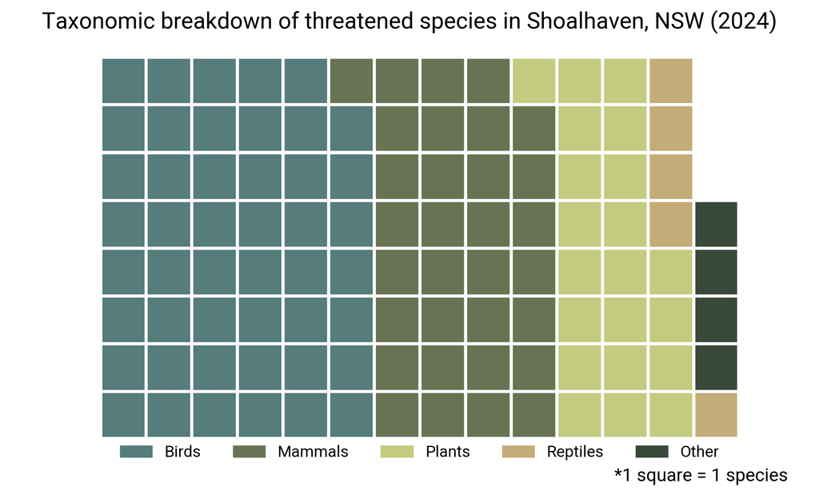

```python
import matplotlib.pyplot as plt
from pywaffle import Waffle
import matplotlib as mpl
from matplotlib import font_manager
from matplotlib import rcParams

# condense all taxa in one column
threatened_status['taxa_for_waffle'] = threatened_status.apply(
              lambda row:
                row['Kingdom'] if (row['Kingdom'] == 'Plantae')
                               else (row['Class'] if row['Class'] in ['Aves','Reptilia','Mammalia'] else 'Other'),
              axis=1
    ).replace({'Aves': 'Birds', 'Reptilia': 'Reptiles', 'Mammalia': 'Mammals','Plantae': 'Plants'})

# import Roboto font into matplotlib
font_files = font_manager.findSystemFonts(fontpaths="Roboto/")
for ff in font_files:
  font_manager.fontManager.addfont(ff)
rcParams['font.family'] = 'Roboto'

# set up the plot
fig,ax = plt.subplots(figsize=(10,6))
status_counts = list(threatened_status['taxa_for_waffle'].value_counts())

# make waffle chart
Waffle.make_waffle(
    ax=ax,
    rows=8,
    values=status_counts,
    colors = ['#567c7c', '#687354', '#C3CB80', '#c4ac79', '#38493a'],
    interval_ratio_x = 0.1,
    interval_ratio_y = 0.1,
    legend={
        'labels': ['Birds', 'Mammals', 'Plants', 'Reptiles', 'Other'],
        'loc': 'lower center',
        'bbox_to_anchor': (0.5,-.1),
        'ncol': 5,
        'framealpha': 0,
        'fontsize': 14
    }
)

# make plot prettier
plt.suptitle('Taxonomic breakdown of threatened species in Shoalhaven, NSW (2024)',fontsize=20,font='Roboto')
fig.text(0.75,0.02,"*1 square = 1 species",fontsize=16)

plt.show()
```

# Final thoughts

We hope this post has helped you understand how to download a species list for a specific area and compare it to conservation lists. It’s also possible to compare species with other information like lists of migratory species or seasonal species.

For other posts, check out [our beginner’s guide to map species observations](https://labs.ala.org.au/posts/2023-12-18_beginners-guide-make-a-map/) or see [an investigation of dingo observations in the ALA](https://labs.ala.org.au/posts/2023-05-16_dingoes/).

**Expand for session info**

```
-----
IPython             9.10.0
galah               0.13.0
geopandas           1.1.2
itables             2.7.0
janitor             0.32.20
matplotlib          3.10.8
natsort             8.4.0
pandas              3.0.1
plotnine            0.15.3
pywaffle            NA
session_info        v1.0.1
shapely             2.1.2
-----
Python 3.14.3 (tags/v3.14.3:323c59a, Feb  3 2026, 16:04:56) [MSC v.1944 64 bit (AMD64)]
Windows-11-10.0.26100-SP0
-----
Session information updated at 2026-03-05 14:02
```

## Footnotes

[^1]: Each spatial layer has a two letter code, along with a number to identify it. The abbreviations are as follows:  
    * `cl` = contextual layer (i.e. boundaries of LGAs, Indigenous Protected Areas, States/Territories etc.)  
    * `11170` = number associated with the spatial layer in the atlas
[^2]: We used `right_join()` this time because we wanted to first select columns from `nsw_threatened`, then join so that we keep all 90+ rows in `threatened` (using `left_join()` would keep all 1,000+ rows in `nsw_threatened` instead).
[^3]: Check out [this post](https://labs.ala.org.au/posts/2023-12-18_beginners-guide-make-a-map/#make-a-map-1) for a better explanation of what CRS is and how it affects maps.
[^4]: Simplifying a shapefile removes the number of total points that draw the shape outline.
[^5]: On a related note, it’s possible to download a list specifically for Shoalhaven on the BioNet Atlas website. However, results from BioNet will be matched BioNet records only. As a result, fewer species will be identifed compared to the ALA, which matches NSW BioNet data *as well as* data from other sources.
[^6]: We can double check status information by viewing the species list in Excel and clicking on links in the `info` column. This is handy for double checking species status codes or learning more about each species and status.
[^7]: This is due to differences in taxonomic names in the externally downloaded list and in ALA data. More info can be found under the “Names Matching” tab in the **Shapefile + list** section.

The ALA is made possible by contributions from its partners, is supported by [NCRIS](https://www.education.gov.au/national-collaborative-research-infrastructure-strategy-ncris), is hosted by [CSIRO](https://csiro.au/), and is the Australian node of [GBIF](https://www.gbif.org/en/).

**Acknowledgement of Traditional Owners and Country**

The Atlas of Living Australia acknowledges Australia's Traditional Owners and pays respect to the past and present Elders of the nation's Aboriginal and Torres Strait Islander communities. We honour and celebrate the spiritual, cultural and customary connections of Traditional Owners to country and the biodiversity that forms part of that country.

This work is licensed under a [Creative Commons Attribution 3.0 Australia License](https://creativecommons.org/licenses/by/3.0/au/)

[Copyright](https://www.ala.org.au/terms-of-use#cy) [Terms of Use](https://www.ala.org.au/terms-of-use) [System Status](https://status.ala.org.au/)